# Session06

Susumu Shikano

Last compiled at 01. August 2022

## Binomial model with discrete prior

```r
 data<- c(10,20)                              # Data: 10 successes in 20 trials
```

We first obtain the posterior by using a discrete prior given the data: 10 out of 20 trials are successful. The prior look like as follows:

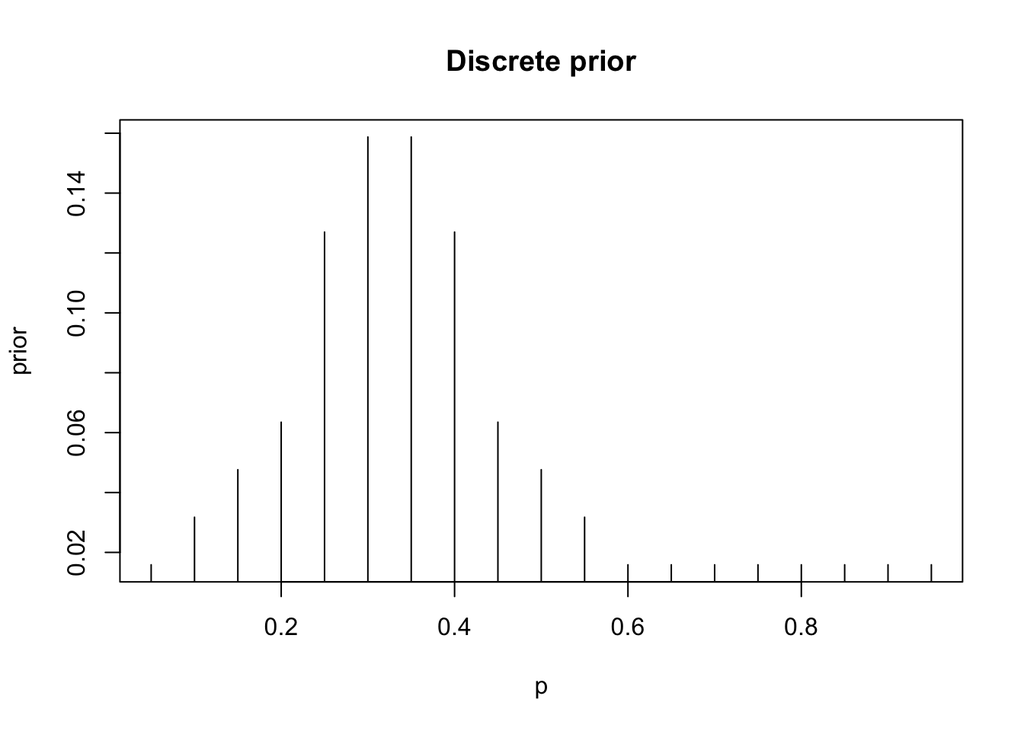

```r
 p <- seq(0.05,0.95,by=0.05)
 prior <- c(1,2,3,4,8,10,10,8,4,3,2,1,1,1,1,1,1,1,1)
 prior <- prior/sum(prior)
 plot(p,prior,type="h",
           main="Discrete prior")
```

The likelihood function is constructed based on the binomial distribution. By multiplying prior and likelihood, subsequently normalizing the product, we can obatin the posterior distribution:

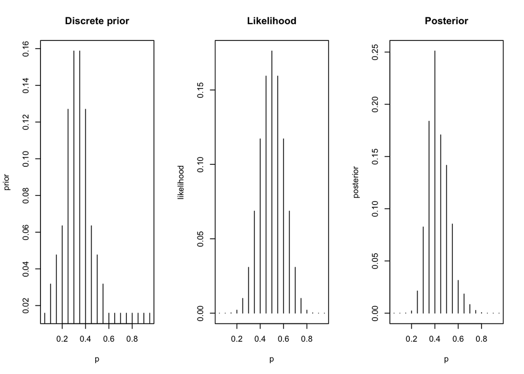

```r
 likeli  <- dbinom(data[1],size=data[2],prob=p)   # likelihood based on binomial distribution

 posterior <- prior * likeli                  # posterior = prior times likelihood
 posterior <- posterior/sum(posterior)        # normalization (sum=1)

par(mfrow=c(1,3))
 plot(p,prior,type="h",
           main="Discrete prior")

 plot(p,likeli,type="h",
           main="Likelihood",ylab="likelihood")

 plot(p,posterior,type="h",
           main="Posterior")
```

## Conjugacy analysis with beta prior: Beta binomial model

We now move to the continuous prior. More specifically, we use the beta distribution to specify prior. Below, you will find posterior based on three different prior and two different data.

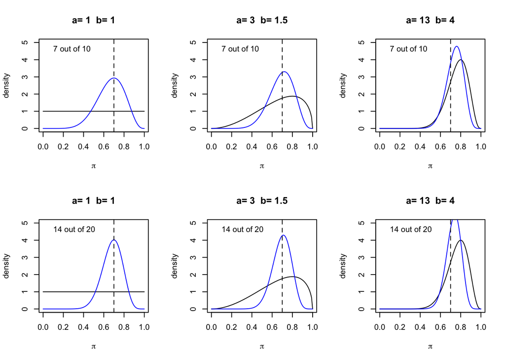

```r
par(mfrow=c(2,3))

for (j in 1:2){
for (i in 1:3){

  if (i==1){
    a <- 1
    b <- 1
  }
  if (i==2){
    a <- 3
    b <- 1.5
  }
  if (i==3){
    a <- 13
    b <- 4
  }


if (j==1) data <- c(7,3)
if (j==2) data <- c(14,6)

y.scale <- c(0,5)


this.dbeta <- function (x) dbeta(x,a,b)
curve(this.dbeta,0,1,ylim=y.scale,ylab="density",xlab=expression(pi),
      main=paste("a=",a," b=",b))

this.dbeta <- function (x) dbeta(x,data[1]+a,data[2]+b)
curve(this.dbeta,0,1,add=T,col="blue")

abline(v=0.7,lty=2)

if (j==1) legend("topleft",paste(data[1],"out of",sum(data)),bty="n")
if (j==2) legend("topleft",paste(data[1],"out of",sum(data)),bty="n")

}
}
```

We can now observe the posterior above more closely and describe in different ways:

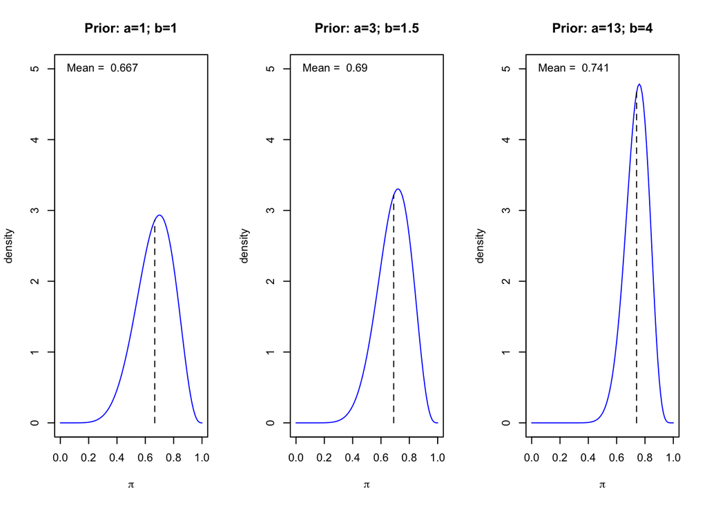

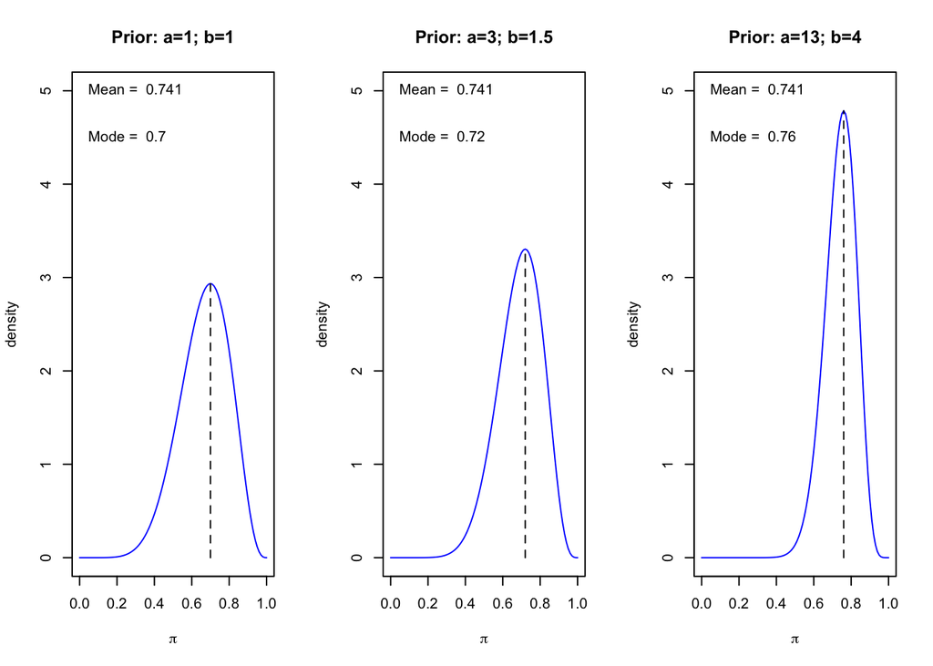

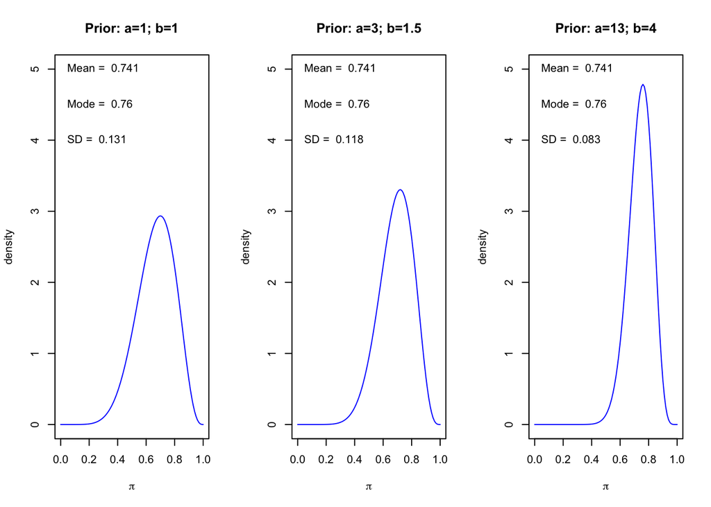

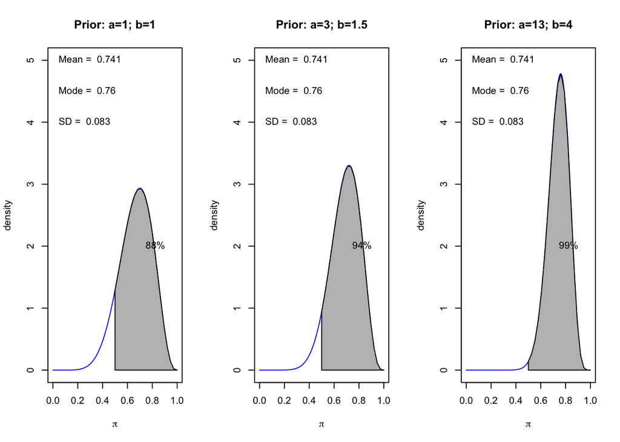

```r
for (i.fig in 1:4){
par(mfrow=c(1,3))

data <- c(7,3)
y.scale <- c(0,5)

for (i.priors in 1:3){
  if (i.priors==1) this.prior <- c(1,1)
  if (i.priors==2) this.prior <- c(3,1.5)
  if (i.priors==3) this.prior <- c(13,4)

  this.dbeta <- function (x) dbeta(x,data[1]+this.prior[1],data[2]+this.prior[2])
  curve(this.dbeta,0,1,col="blue",ylim=y.scale,ylab="density",xlab=expression(pi),
        main=paste0("Prior: a=",this.prior[1],"; b=",this.prior[2]))

  post.a <-data[1]+this.prior[1]
  post.d <- data[2]+this.prior[2]

  if (i.fig==1) this.mean <- this.stat <-  (data[1]+this.prior[1])/(sum(this.prior)+sum(data))
  if (i.fig==2) this.mode <- this.stat <-  (data[1]+this.prior[1] -1)/(sum(this.prior)+sum(data)-2)
  if (i.fig==3) this.sd <- this.stat <-  sqrt((post.a)*(post.d)/((post.a + post.d + 1)*(post.a + post.d)^2))
  if (i.fig==1|i.fig==2) lines(rep(this.stat,2),c(0,this.dbeta(this.stat)),lty=2)
  if (i.fig>=1) text(0,max(y.scale),paste("Mean = ",round(this.mean,3)),pos=4)
  if (i.fig>=2) text(0,max(y.scale)-.5,paste("Mode = ",round(this.mode,3)),pos=4)
  if (i.fig>=3) text(0,max(y.scale)-1,paste("SD = ",round(this.sd,3)),pos=4)

  if (i.fig==4){
    xvals <- seq(0.5, 1, length=20)
    dvals <- this.dbeta(xvals)
    polygon(c(xvals,rev(xvals)),
            c(rep(0,20),rev(dvals)),col="gray")
    #text(0,max(y.scale)-1.5,expression(paste0(Pr(pi>0.5)),"?"),pos=4)
    over.5 <- mean(ifelse(rbeta(1000,post.a,post.d)>0.5,1,0))
    text(0.7,2,paste0(round(over.5*100),"%"),pos=4)

  }
}
}
```

## Regression analysis

To conduct the regression analysis, we first read the exam data:

```r
load("../data/Statistics_Exam_Anonymous.RData")


y <- exam.anonym$points[!is.na(exam.anonym$points)]
x <- exam.anonym$worksheet_submitted[!is.na(exam.anonym$points)]
x.mat <- cbind(1,x)


n <- length(y)
```

Let’s set up the prior:

```r
mu0 <- c(0,0)

sigma0 <- rbind(c(0,    1000000),
                c(1000000,    0))

a0 <- 0.000001
d0 <- 0.000001
```

- $\mu^* = (\Sigma_0^{-1} + x' x )^{-1} ({\Sigma_0^{-1}} {\mu_0} + x' y )$

```r
print(mu.star <- solve(solve(sigma0) + t(x.mat)%*%x.mat )%*% (solve(sigma0)%*%mu0 + t(x.mat)%*%y))
```

```
##        [,1]
##   39.609073
## x  4.347835
```

```r
print(sigma.star <- solve(solve(sigma0) + t(x.mat)%*%x.mat ))
```

```
##                            x
##    0.042016426 -0.0057974042
## x -0.005797404  0.0009079725
```

- $a^* = a_0 + \frac{1}{2}( {\mu'_0} {\Sigma}_0^{-1} {\mu_0} + y'y - {\mu^{*'}} {\Sigma}^{*-1} {\mu^*} )$

```r
print(a.star <- a0 + 0.5*(t(mu0)%*%solve(sigma0)%*%mu0 + t(y)%*%y  - t(mu.star) %*%solve(sigma.star)%*%mu.star))
```

```
##          [,1]
## [1,] 41530.48
```

- $d^* = d_0 + \frac{n}{2}$

```r
print(d.star <- d0 + n/2)
```

```
## [1] 100
```

Here, we have posterior mean for $\beta_0$ and $\beta_1$ in the joint distribution:

```r
mu.star
```

```
##        [,1]
##   39.609073
## x  4.347835
```

What we in general report is the marginal distribution. To obtain the marginal distribution of $\beta$s, we integrate out $\sigma^2$ from the joint distribution:
$$f(\beta | y) =
\int^\infty_0 f(\beta, \sigma^2| y) d \sigma^2 =
f_t\left(\nu, {\mu^*} , \frac{a^*}{d^*}{\Sigma}^*\right)$$

While the point estimates of $\beta$s are unaffected, the standard error is obtained from: $\frac{a^*}{d^*}{\Sigma}^*$:

```r
sqrt(diag(sigma.star) * a.star/d.star)
```

```
##                   x
## 4.1772748 0.6140728
```

We can now compare this result with the results based on the OLS estimator:

```r
summary(lm(y  ~ x))
```

```
##
## Call:
## lm(formula = y ~ x)
##
## Residuals:
##    Min     1Q Median     3Q    Max
## -56.70 -12.90   4.00  13.91  51.39
##
## Coefficients:
##             Estimate Std. Error t value Pr(>|t|)
## (Intercept)  39.6091     4.1983   9.435   <2e-16 ***
## x             4.3478     0.6172   7.045    3e-11 ***
## ---
## Signif. codes:  0 '***' 0.001 '**' 0.01 '*' 0.05 '.' 0.1 ' ' 1
##
## Residual standard error: 20.48 on 198 degrees of freedom
## Multiple R-squared:  0.2004, Adjusted R-squared:  0.1964
## F-statistic: 49.63 on 1 and 198 DF,  p-value: 3.001e-11
```